# Machine Learning with `R`

# Linear and Quadratic Discriminant Analyses (LDA and QDA)

# Linear Discriminant Analysis (LDA)

In LDA, the distribution of the predictors $X$ are modeled separately in each of the response classes (i.e. given $Y$), and then a rule from probability theory, known as Bayes’ theorem, is used to turn these into estimates for $Pr(Y = k|X = x)$, called “posterior” probabilities. More specifically, Bayes’ theorem allows to obtain the posterior probabilities by combining “prior” probabilities with the evidence coming from the data. Every observation is then assigned to the class with the highest posterior probability.

Alternatively, following the formulation by Fisher, the goal of LDA can also be stated as finding a linear combination $w$ of the predictors that maximizes the separation between the centers of the data while at the same time minimizing the variation within each group of data after projection onto $w$. Recall that the first principal component is the direction that maximizes the projected variance of the points. The key difference between PCA and LDA is that the former deals with unlabeled data and tries to maximize variance, whereas the latter deals with labeled data and tries to maximize the discrimination between the classes.

The assumption in LDA is that the predictors’ covariance matrices within each class are equal.

In LDA the unknown parameters of the multivariate normal distributions of each class have to be first estimated. These estimates are then used to find the decision boundaries based on which observations are assigned to the different classes. These boundaries are determined by the so called “Fisher’s linear discriminant function”.

To perform LDA on Credit Card data, we use the `lda()` function of the `MASS` package. This function requires to set a formula that specifies the categorical response and the predictors to use, the data frame containing the data, and a series of other optional arguments, such as the method to use for estimation and the prior probabilities for each class (if the prior argument is not specified, the class proportions for the training set are used):

## Example: Credit Card Default

We will try the LDA on the `Default` dataset:

```r
require(MASS)
```

```r
summary(Default)
```

```
##  default    student       balance           income
##  No :9667   No :7056   Min.   :   0.0   Min.   :  772
##  Yes: 333   Yes:2944   1st Qu.: 481.7   1st Qu.:21340
##                        Median : 823.6   Median :34553
##                        Mean   : 835.4   Mean   :33517
##                        3rd Qu.:1166.3   3rd Qu.:43808
##                        Max.   :2654.3   Max.   :73554
```

```r
res <- lda(default ~ student + balance, data = Default)
res
```

```
## Call:
## lda(default ~ student + balance, data = Default)
##
## Prior probabilities of groups:
##     No    Yes
## 0.9667 0.0333
##
## Group means:
##     studentYes   balance
## No   0.2914037  803.9438
## Yes  0.3813814 1747.8217
##
## Coefficients of linear discriminants:
##                     LD1
## studentYes -0.249059498
## balance     0.002244397
```

The output (an object of class `lda`) shows that non-students with a higher balance are more likely to default. To classify the observations to either of the two classes, we use the `predict()` function:

```r
default_hat <- predict(res)$class
```

And now we can assess the goodness of the classification:

```r
table(default_hat, Default$default)
```

```
##
## default_hat   No  Yes
##         No  9644  252
##         Yes   23   81
```

Elements on the diagonal of the matrix represent individuals whose default statuses were correctly predicted, while off-diagonal elements represent individuals that were misclassified. So, the LDA model fit to the 10,000 observations results in an error rate of (23 + 252)/10,000 = 0.0275, i.e. a 2.75%. This sounds like a low error rate, but two caveats must be noted:

1. First, error rates for the observations used in estimation are typically expected to be smaller than if we use the model to predict whether or not a new set of individuals will default. The reason is that we specifically adjust the parameters of our model to do well on the “training” data;
2. Second, since only 3.33% of the individuals in the training sample defaulted, a simple but useless classifier that always predicts that each individual will not default, regardless of his or her credit card balance and student status, will result in an error rate of 3.33%. In other words, the trivial null classifier will achieve an error rate that is only a bit higher than the LDA training set error rate.

However, of the 333 individuals who defaulted, 252 (or 252/333 = 0.757) were missed by LDA. So, while the overall error rate is low, the error rate among individuals who defaulted is very high. From the perspective of a credit card company that is trying to identify high-risk individuals, an error rate of 75.7% among individuals who default might be unacceptable. A further way to assess class-specific performance uses the concepts of sensitivity" and “specificity”. The sensitivity is the percentage of true defaulters that are identified, in the example equal to 81/(252 + 81) = 0.243. The specificity is the percentage of non-defaulters that are correctly identified, in the example equal to 9,644/(9,644 + 23) = 0.998.

In the `caret` package we find the `confusionMatrix()` function that calculates automatically the table and other statistics related to the classification problem:

```r
require(caret)
```

```r
confusionMatrix(data = default_hat, reference = Default$default,
                positive = "Yes")
```

```
## Confusion Matrix and Statistics
##
##           Reference
## Prediction   No  Yes
##        No  9644  252
##        Yes   23   81
##
##                Accuracy : 0.9725
##                  95% CI : (0.9691, 0.9756)
##     No Information Rate : 0.9667
##     P-Value [Acc > NIR] : 0.0004973
##
##                   Kappa : 0.3606
##  Mcnemar's Test P-Value : < 2.2e-16
##
##             Sensitivity : 0.2432
##             Specificity : 0.9976
##          Pos Pred Value : 0.7788
##          Neg Pred Value : 0.9745
##              Prevalence : 0.0333
##          Detection Rate : 0.0081
##    Detection Prevalence : 0.0104
##       Balanced Accuracy : 0.6204
##
##        'Positive' Class : Yes
##
```

To understand why LDA is performing so poorly (especially from the sensitivity point of view), note that in this example we are particularly concerned with the misclassification of individuals who actually default, whereas the misclassification of individuals who will not default is less problematic. So far, to assign an observation to the default class, we used a threshold of 50% for the posterior probability of default. One possibility to improve the sensitivity of this classifier is to lower this threshold. For instance, we might label any customer with a posterior probability of default above 20% to the default class. Doing this we would get the following results:

```r
post <- predict(res)$posterior
threshold <- 0.2
default_hat_20 <- as.factor(ifelse(post[, 2] > threshold, 1, 0))
levels(default_hat_20) <- c("No", "Yes")
prop.table(table(default_hat_20, Default$default), margin = 2)
```

```
##
## default_hat_20         No        Yes
##            No  0.97569049 0.41441441
##            Yes 0.02430951 0.58558559
```

```r
confusionMatrix(data = default_hat_20, reference = Default$default,
                positive = "Yes")
```

```
## Confusion Matrix and Statistics
##
##           Reference
## Prediction   No  Yes
##        No  9432  138
##        Yes  235  195
##
##                Accuracy : 0.9627
##                  95% CI : (0.9588, 0.9663)
##     No Information Rate : 0.9667
##     P-Value [Acc > NIR] : 0.9869
##
##                   Kappa : 0.4921
##  Mcnemar's Test P-Value : 6.671e-07
##
##             Sensitivity : 0.5856
##             Specificity : 0.9757
##          Pos Pred Value : 0.4535
##          Neg Pred Value : 0.9856
##              Prevalence : 0.0333
##          Detection Rate : 0.0195
##    Detection Prevalence : 0.0430
##       Balanced Accuracy : 0.7806
##
##        'Positive' Class : Yes
##
```

Of the 333 individuals who default, now LDA correctly predicts all but 138, 41.4%). This is a huge improvement! However, this improvement has a price: now 235 individuals who do not default are incorrectly classified. As a result, the overall error rate has increased slightly to 3.73%. Probably this might be considered a small price to pay for a more accurate identification of individuals who default. The key question now is how to choose which threshold value is best. Unfortunately there is no immediate answer, because this decision must be based on domain knowledge, such as detailed information about the costs associated with default.

A popular tool for assessing the performance of a classifier is the “receiver operating characteristics” curve (or ROC curve). This is a graph that simultaneously displays both the sensitivity and specificity for all possible thresholds. More specifically, the ROC curves reports on the vertical axis the sensitivity and on the horizontal axis one minus the specificity corresponding to many different thresholds ranging from zero to 1. ROC curves are useful for comparing different classifiers. A synthesis of the overall performance of a classifier is given by the area under the ROC curve (AUC). An ideal ROC curve will get to the top left corner, so the larger the AUC the better the classifier. There are many `R` packages that include functions for producing a ROC curve. One of the easiest to use is the `pROC` package:

```r
require(pROC)
```

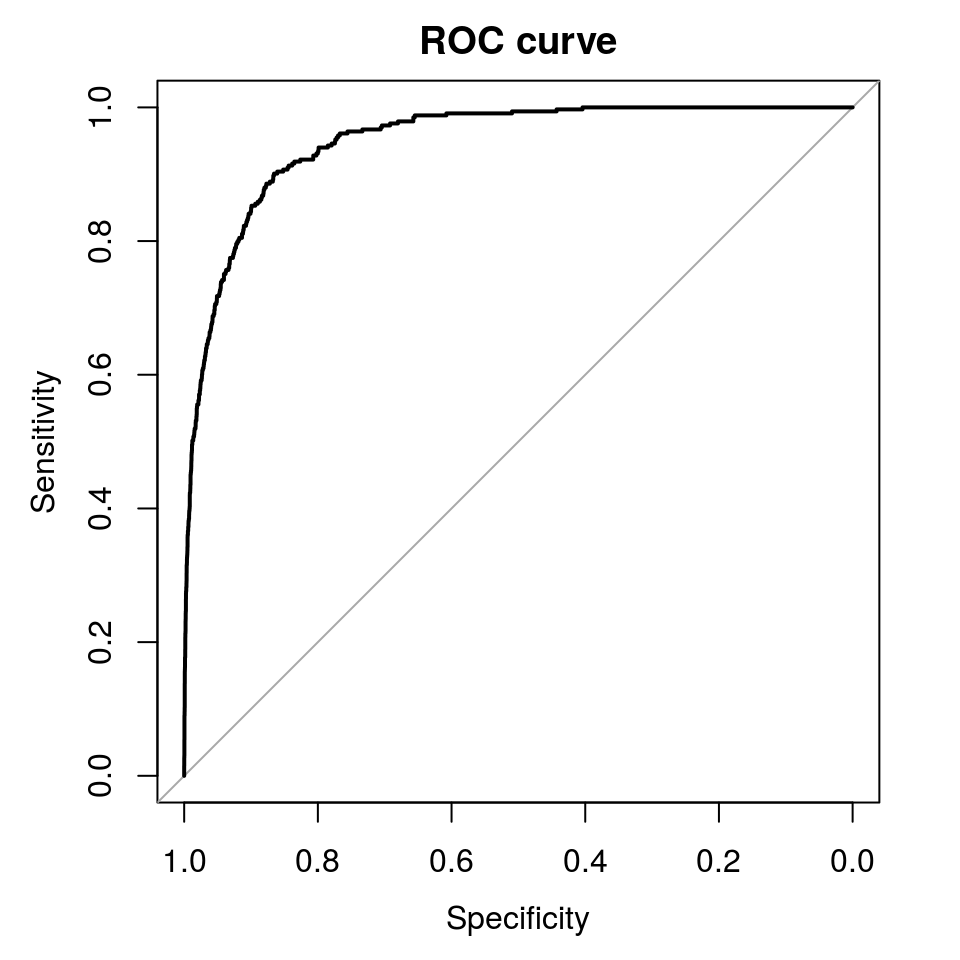

```
##
## Call:
## roc.default(response = Default$default, predictor = post[, 2],     auc = TRUE, ci = TRUE, plot = TRUE, main = "ROC curve")
##
## Data: post[, 2] in 9667 controls (Default$default No) < 333 cases (Default$default Yes).
## Area under the curve: 0.9496
## 95% CI: 0.9401-0.959 (DeLong)
```

```r
roc(response = Default$default, predictor = post[, 2], auc = TRUE, ci = TRUE,
    plot = TRUE, main = "ROC curve")
```

The AUC for our example is around 0.95, which is pretty close to the maximum attainable value of 1, so would be considered very good. Note that this function produces a ROC curve reporting the specificity on the horizontal axis, which is then reversed. To produce a standard ROC curve with (1 - specificity) reported on the horizontal axis, use the argument `legacy.axes = TRUE`.

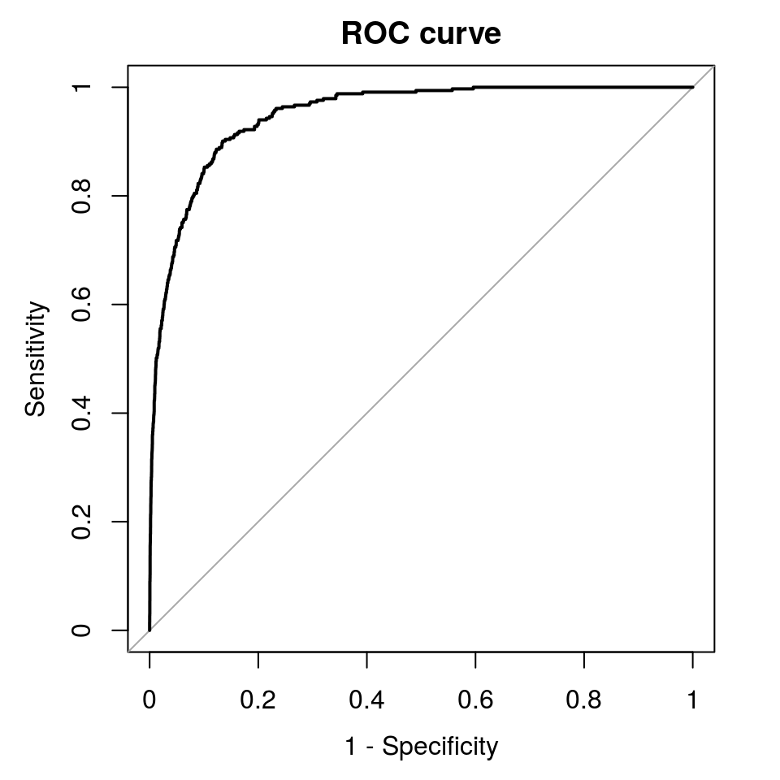

```
##
## Call:
## roc.default(response = Default$default, predictor = post[, 2],     auc = TRUE, ci = TRUE, plot = TRUE, main = "ROC curve", legacy.axes = TRUE)
##
## Data: post[, 2] in 9667 controls (Default$default No) < 333 cases (Default$default Yes).
## Area under the curve: 0.9496
## 95% CI: 0.9401-0.959 (DeLong)
```

```r
roc(response = Default$default, predictor = post[, 2], auc = TRUE, ci = TRUE,
    plot = TRUE, main = "ROC curve", legacy.axes = TRUE)
```

To compare these results with a competing classifier, let’s add to the predictor set also the income of the customers that we excluded in the previous analysis:

```r
res_new <- lda(default ~ ., data = Default)
res_new
```

```
## Call:
## lda(default ~ ., data = Default)
##
## Prior probabilities of groups:
##     No    Yes
## 0.9667 0.0333
##
## Group means:
##     studentYes   balance   income
## No   0.2914037  803.9438 33566.17
## Yes  0.3813814 1747.8217 32089.15
##
## Coefficients of linear discriminants:
##                      LD1
## studentYes -1.746631e-01
## balance     2.243541e-03
## income      3.367310e-06
```

```r
post_new <- predict(res_new)$posterior
# plot the ROC fot original model
roc(response = Default$default, predictor = post[, 2], auc = TRUE, ci = TRUE,
    plot = TRUE, col = "magenta", main = "ROC comparison")
```

```
##
## Call:
## roc.default(response = Default$default, predictor = post[, 2],     auc = TRUE, ci = TRUE, plot = TRUE, col = "magenta", main = "ROC comparison")
##
## Data: post[, 2] in 9667 controls (Default$default No) < 333 cases (Default$default Yes).
## Area under the curve: 0.9496
## 95% CI: 0.9401-0.959 (DeLong)
```

```r
# add the ROC fot new model
roc(response = Default$default, predictor = post_new[, 2], auc = TRUE,
    ci = TRUE, plot = TRUE, col = "cyan", add = TRUE)
```

```
##
## Call:
## roc.default(response = Default$default, predictor = post_new[,     2], auc = TRUE, ci = TRUE, plot = TRUE, col = "cyan", add = TRUE)
##
## Data: post_new[, 2] in 9667 controls (Default$default No) < 333 cases (Default$default Yes).
## Area under the curve: 0.9495
## 95% CI: 0.9401-0.9589 (DeLong)
```

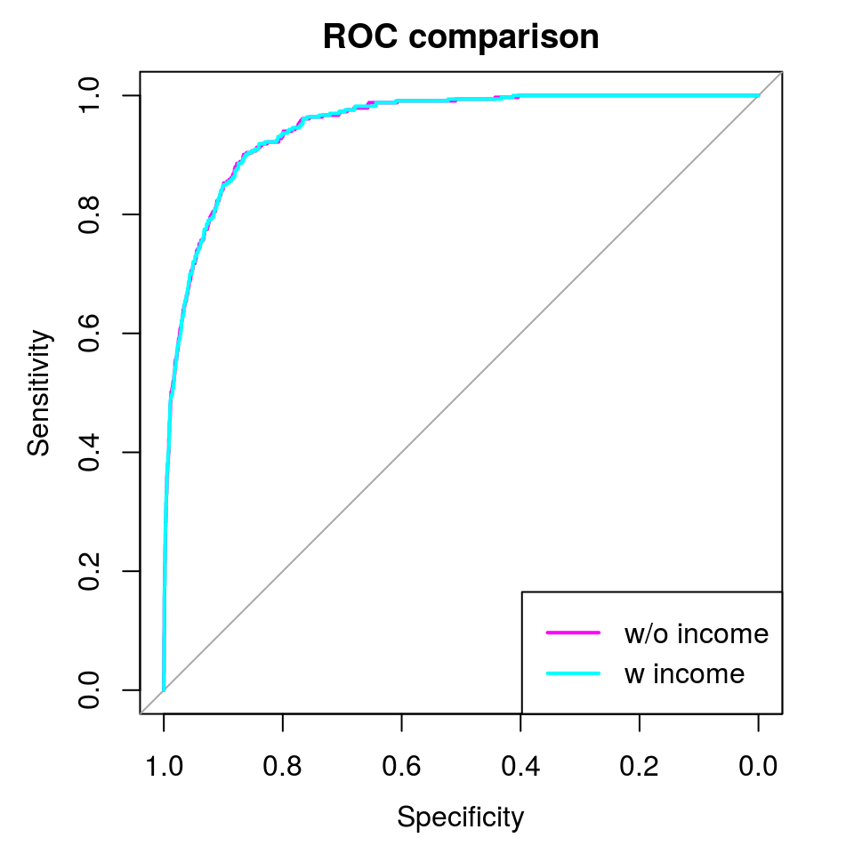

```r
legend(x = "bottomright", legend = c("w/o income", "w income"),
       col = c("magenta", "cyan"), lty = rep(1, 2), lwd = rep(2, 2))
```

The two ROC curves and the corresponding AUC are indistinguishable, therefore it seems that the addition of income doesn’t help to better discriminate the two groups. Other comparisons could be made with further models for classification like the logistic regression previously estimated, which in this example would return the same results:

```r
res_logit <- glm(default ~ student + balance, data = Default,
                 family = binomial(link = logit))
post_logit <- predict(res_logit, type = "response")
roc(response = Default$default, predictor = post[, 2], auc = TRUE, ci = TRUE,
    plot = TRUE, col = "magenta", main = "ROC comparison")
```

```
##
## Call:
## roc.default(response = Default$default, predictor = post[, 2],     auc = TRUE, ci = TRUE, plot = TRUE, col = "magenta", main = "ROC comparison")
##
## Data: post[, 2] in 9667 controls (Default$default No) < 333 cases (Default$default Yes).
## Area under the curve: 0.9496
## 95% CI: 0.9401-0.959 (DeLong)
```

```r
roc(response = Default$default, predictor = post_logit, auc = TRUE,
    ci = TRUE, plot = TRUE, col = "cyan", add = TRUE)
```

```
##
## Call:
## roc.default(response = Default$default, predictor = post_logit,     auc = TRUE, ci = TRUE, plot = TRUE, col = "cyan", add = TRUE)
##
## Data: post_logit in 9667 controls (Default$default No) < 333 cases (Default$default Yes).
## Area under the curve: 0.9495
## 95% CI: 0.9401-0.959 (DeLong)
```

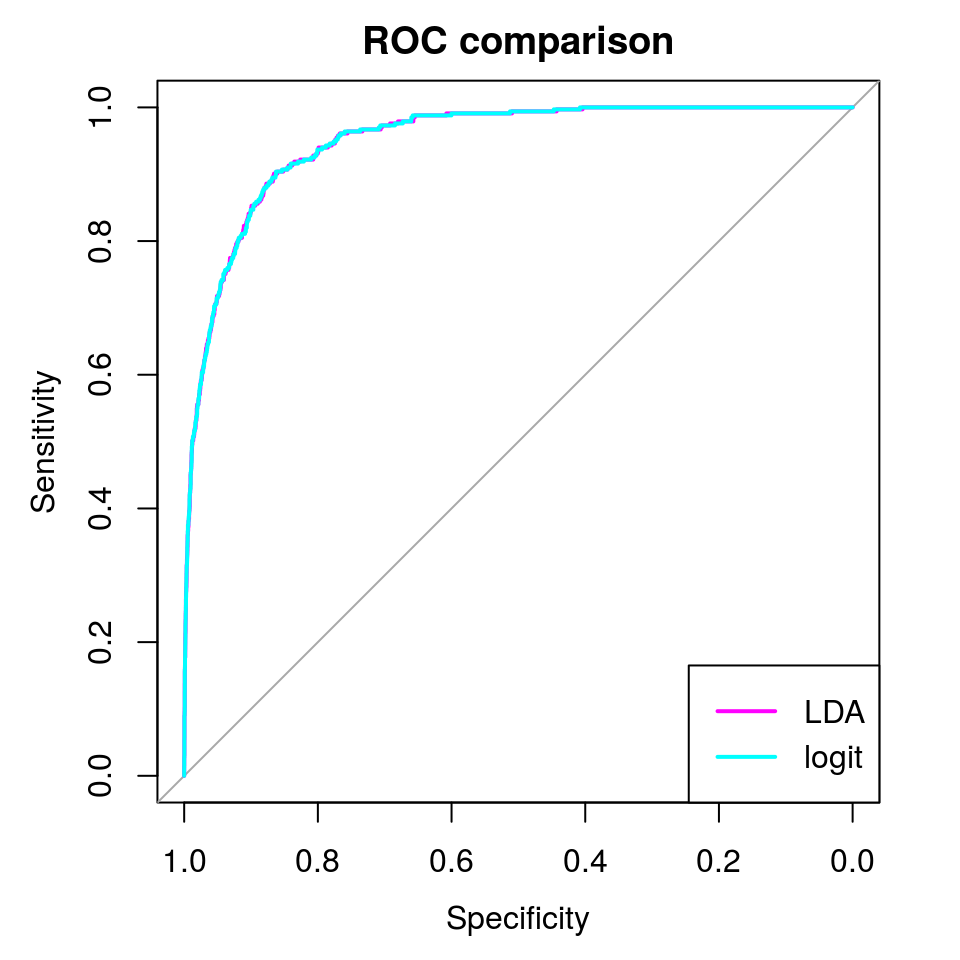

```r
legend(x = "bottomright", legend = c("LDA", "logit"),
       col = c("magenta", "cyan"), lty = rep(1, 2), lwd = rep(2, 2))
```

A more appropriate assessment of the predictive ability of these methods would involve the comparison of the error rate on a separate “test” set. This can be achieved by specifying the ‘subset’ argument in the `lda()` function.

# An Extension: Quadratic Discriminant Analysis (QDA)

QDA relaxes one the main assumption of LDA by assuming that each class has its own covariance matrix. This modification gives rise to decision boundaries that in QDA are quadratic functions of the predictors. Why would one prefer LDA or QDA? The answer involves a trade-off between bias and variance of the predictions. Roughly speaking, LDA tends to produce better results than QDA if there are relatively few training observations and so reducing variance is crucial. In contrast, QDA is recommended if the training set is larger, so that the variance of the classifier is not a major concern.

The function `qda()` in the `MASS` package performs QDA:

```r
res_qda <- qda(default ~ student + balance, data = Default)
post_qda <- predict(res_qda)$posterior
threshold <- 0.2
default.qda <- as.factor(ifelse(post_qda[, 2] > threshold, 1, 0))
levels(default.qda) <- c("No", "Yes")
prop.table(table(default.qda, Default$default), margin = 2)
```

```
##
## default.qda         No        Yes
##         No  0.96638047 0.35735736
##         Yes 0.03361953 0.64264264
```

```r
confusionMatrix(data = default.qda, reference = Default$default,
                positive = "Yes")
```

```
## Confusion Matrix and Statistics
##
##           Reference
## Prediction   No  Yes
##        No  9342  119
##        Yes  325  214
##
##                Accuracy : 0.9556
##                  95% CI : (0.9514, 0.9596)
##     No Information Rate : 0.9667
##     P-Value [Acc > NIR] : 1
##
##                   Kappa : 0.469
##  Mcnemar's Test P-Value : <2e-16
##
##             Sensitivity : 0.6426
##             Specificity : 0.9664
##          Pos Pred Value : 0.3970
##          Neg Pred Value : 0.9874
##              Prevalence : 0.0333
##          Detection Rate : 0.0214
##    Detection Prevalence : 0.0539
##       Balanced Accuracy : 0.8045
##
##        'Positive' Class : Yes
##
```

```r
roc(response = Default$default, predictor = post[, 2], auc = TRUE, ci = TRUE,
    plot = TRUE, col = "magenta", main = "ROC comparison")
```

```
##
## Call:
## roc.default(response = Default$default, predictor = post[, 2],     auc = TRUE, ci = TRUE, plot = TRUE, col = "magenta", main = "ROC comparison")
##
## Data: post[, 2] in 9667 controls (Default$default No) < 333 cases (Default$default Yes).
## Area under the curve: 0.9496
## 95% CI: 0.9401-0.959 (DeLong)
```

```r
roc(response = Default$default, predictor = post_qda[, 2], auc = TRUE,
    ci = TRUE, plot = TRUE, col = "cyan", add = TRUE)
```

```
##
## Call:
## roc.default(response = Default$default, predictor = post_qda[,     2], auc = TRUE, ci = TRUE, plot = TRUE, col = "cyan", add = TRUE)
##
## Data: post_qda[, 2] in 9667 controls (Default$default No) < 333 cases (Default$default Yes).
## Area under the curve: 0.9495
## 95% CI: 0.9401-0.9589 (DeLong)
```

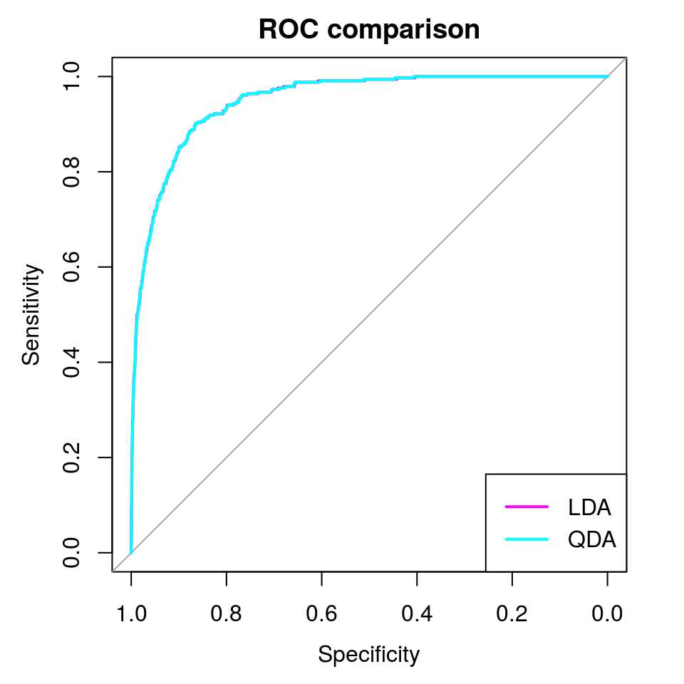

```r
legend(x = "bottomright", legend = c("LDA", "QDA"),
       col = c("magenta", "cyan"), lty = rep(1, 2), lwd = rep(2, 2))
```

## Example: Stock Market Data

We consider now `Smarket` (see the section *Introduction and datasets used* for further information), a second dataset consisting of percentage returns for the S&P 500 stock index over 1,250 days, from the beginning of 2001 until the end of 2005. For each date, the percentage returns for each of the five previous trading days (Lag1 through Lag5), the number of shares traded on the previous day (Volume, in billions), the percentage return on the date in question (Today) and whether the market was up or down on this date (Direction) have been recorded:

```r
require(GGally)
```

```r
summary(Smarket)
```

```
##       Year           Lag1                Lag2                Lag3                Lag4
##  Min.   :2001   Min.   :-4.922000   Min.   :-4.922000   Min.   :-4.922000   Min.   :-4.922000
##  1st Qu.:2002   1st Qu.:-0.639500   1st Qu.:-0.639500   1st Qu.:-0.640000   1st Qu.:-0.640000
##  Median :2003   Median : 0.039000   Median : 0.039000   Median : 0.038500   Median : 0.038500
##  Mean   :2003   Mean   : 0.003834   Mean   : 0.003919   Mean   : 0.001716   Mean   : 0.001636
##  3rd Qu.:2004   3rd Qu.: 0.596750   3rd Qu.: 0.596750   3rd Qu.: 0.596750   3rd Qu.: 0.596750
##  Max.   :2005   Max.   : 5.733000   Max.   : 5.733000   Max.   : 5.733000   Max.   : 5.733000
##       Lag5              Volume           Today           Direction
##  Min.   :-4.92200   Min.   :0.3561   Min.   :-4.922000   Down:602
##  1st Qu.:-0.64000   1st Qu.:1.2574   1st Qu.:-0.639500   Up  :648
##  Median : 0.03850   Median :1.4229   Median : 0.038500
##  Mean   : 0.00561   Mean   :1.4783   Mean   : 0.003138
##  3rd Qu.: 0.59700   3rd Qu.:1.6417   3rd Qu.: 0.596750
##  Max.   : 5.73300   Max.   :3.1525   Max.   : 5.733000
```

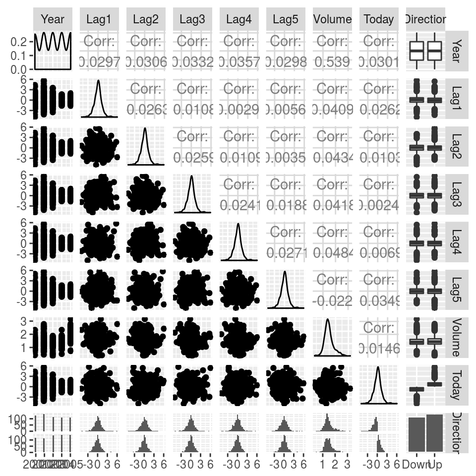

```r
ggpairs(Smarket)
```

The correlations between the lag variables and today’s returns are close to zero. The only non negligible correlation is between Year and Volume, because the average number of shares traded daily increased from 2001 to 2005:

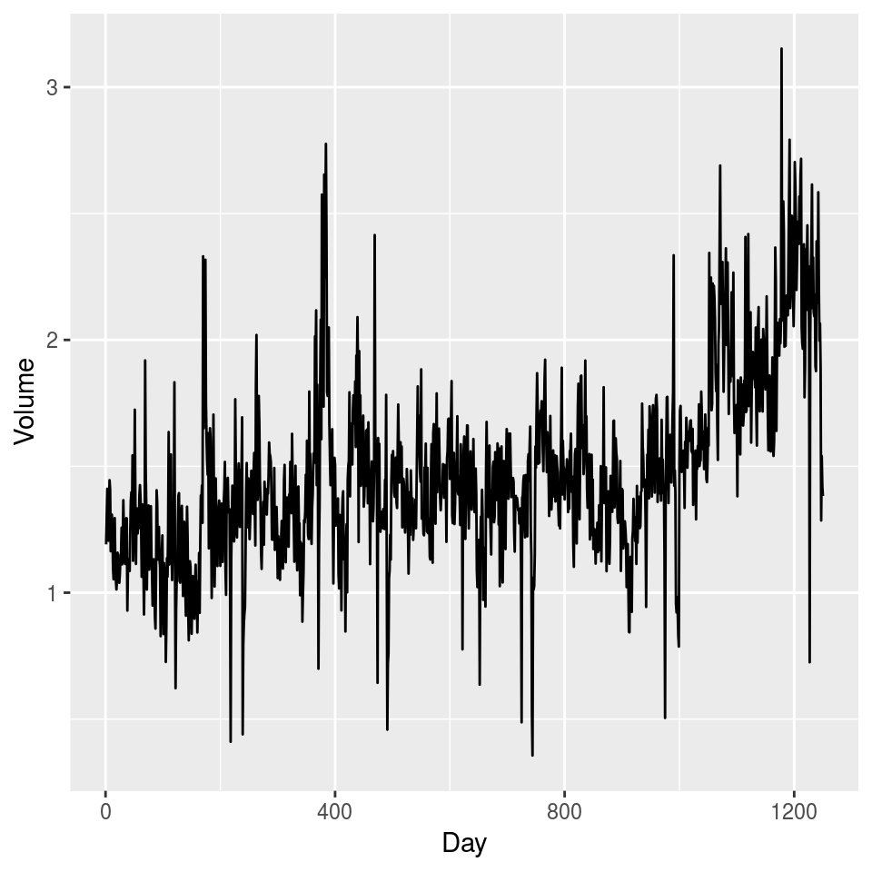

```r
ggp <- ggplot(Smarket, aes(x = 1:length(Volume), y = Volume)) + geom_line() +
    xlab("Day")
plot(ggp)
```

We aim to predict the `Direction` values using `Lag1` through `Lag5` and `Volume`. To this end, we’ll compare the results from logistic regression, LDA and QDA. We start with logistic regression:

```r
glm_fit <- glm(Direction ~ Lag1 + Lag2 + Lag3 + Lag4 + Lag5 + Volume,
               data = Smarket, family = binomial(link = logit))
summary(glm_fit)
```

```
##
## Call:
## glm(formula = Direction ~ Lag1 + Lag2 + Lag3 + Lag4 + Lag5 +
##     Volume, family = binomial(link = logit), data = Smarket)
##
## Deviance Residuals:
##    Min      1Q  Median      3Q     Max
## -1.446  -1.203   1.065   1.145   1.326
##
## Coefficients:
##              Estimate Std. Error z value Pr(>|z|)
## (Intercept) -0.126000   0.240736  -0.523    0.601
## Lag1        -0.073074   0.050167  -1.457    0.145
## Lag2        -0.042301   0.050086  -0.845    0.398
## Lag3         0.011085   0.049939   0.222    0.824
## Lag4         0.009359   0.049974   0.187    0.851
## Lag5         0.010313   0.049511   0.208    0.835
## Volume       0.135441   0.158360   0.855    0.392
##
## (Dispersion parameter for binomial family taken to be 1)
##
##     Null deviance: 1731.2  on 1249  degrees of freedom
## Residual deviance: 1727.6  on 1243  degrees of freedom
## AIC: 1741.6
##
## Number of Fisher Scoring iterations: 3
```

```r
glm_probs <- predict(glm_fit, type = "response")
glm_pred <- rep("Down", nrow(Smarket))
glm_pred[glm_probs > .5] <- "Up"
confusionMatrix(data = glm_pred, reference = Smarket$Direction,
                positive = "Up")
```

```
## Confusion Matrix and Statistics
##
##           Reference
## Prediction Down  Up
##       Down  145 141
##       Up    457 507
##
##                Accuracy : 0.5216
##                  95% CI : (0.4935, 0.5496)
##     No Information Rate : 0.5184
##     P-Value [Acc > NIR] : 0.4216
##
##                   Kappa : 0.0237
##  Mcnemar's Test P-Value : <2e-16
##
##             Sensitivity : 0.7824
##             Specificity : 0.2409
##          Pos Pred Value : 0.5259
##          Neg Pred Value : 0.5070
##              Prevalence : 0.5184
##          Detection Rate : 0.4056
##    Detection Prevalence : 0.7712
##       Balanced Accuracy : 0.5116
##
##        'Positive' Class : Up
##
```

```r
train <- (Smarket$Year < 2005)
Smarket_2005 <- Smarket[!train, ]
glm_fit <- glm(Direction ~Lag1 + Lag2 + Lag3 + Lag4 + Lag5 + Volume,
               data = Smarket, family = binomial(link = logit), subset = train)
glm_probs <- predict(glm_fit, Smarket_2005, type = "response")
glm_pred <- rep("Down", nrow(Smarket_2005))
glm_pred[glm_probs > .5] <- "Up"
confusionMatrix(data = glm_pred, reference = Smarket_2005$Direction,
                positive = "Up")
```

```
## Confusion Matrix and Statistics
##
##           Reference
## Prediction Down Up
##       Down   77 97
##       Up     34 44
##
##                Accuracy : 0.4802
##                  95% CI : (0.417, 0.5437)
##     No Information Rate : 0.5595
##     P-Value [Acc > NIR] : 0.9952
##
##                   Kappa : 0.0054
##  Mcnemar's Test P-Value : 6.062e-08
##
##             Sensitivity : 0.3121
##             Specificity : 0.6937
##          Pos Pred Value : 0.5641
##          Neg Pred Value : 0.4425
##              Prevalence : 0.5595
##          Detection Rate : 0.1746
##    Detection Prevalence : 0.3095
##       Balanced Accuracy : 0.5029
##
##        'Positive' Class : Up
##
```

The test error rate is 52%, which is worse than random guessing! This result is not that surprising, since it is a well known fact that one would not generally expect to be able to use previous days’ returns to predict future market performance. As an attempt to improve the model, we remove the predictors with the highest p-values refitting the logistic regression using just `Lag1` and `Lag2`:

```r
glm_fit <- glm(Direction ~ Lag1 + Lag2, data = Smarket,
               family = binomial(link = logit), subset = train)
glm_probs <- predict(glm_fit, Smarket_2005, type = "response")
glm_pred <- rep("Down", nrow(Smarket_2005))
glm_pred[glm_probs > .5] <- "Up"
confusionMatrix(data = glm_pred, reference = Smarket_2005$Direction,
                positive = "Up")
```

```
## Confusion Matrix and Statistics
##
##           Reference
## Prediction Down  Up
##       Down   35  35
##       Up     76 106
##
##                Accuracy : 0.5595
##                  95% CI : (0.4959, 0.6218)
##     No Information Rate : 0.5595
##     P-Value [Acc > NIR] : 0.5262856
##
##                   Kappa : 0.0698
##  Mcnemar's Test P-Value : 0.0001467
##
##             Sensitivity : 0.7518
##             Specificity : 0.3153
##          Pos Pred Value : 0.5824
##          Neg Pred Value : 0.5000
##              Prevalence : 0.5595
##          Detection Rate : 0.4206
##    Detection Prevalence : 0.7222
##       Balanced Accuracy : 0.5335
##
##        'Positive' Class : Up
##
```

Now 56% of the daily movements have been correctly predicted.

We now perform LDA using only the observations before 2005:

```r
lda_fit <- lda(Direction ~ Lag1 + Lag2, data = Smarket, subset = train)
lda_probs <- predict(lda_fit, Smarket_2005)$posterior[, 2]
lda_class <- predict(lda_fit, Smarket_2005)$class
confusionMatrix(data = lda_class, reference = Smarket_2005$Direction,
                positive = "Up")
```

```
## Confusion Matrix and Statistics
##
##           Reference
## Prediction Down  Up
##       Down   35  35
##       Up     76 106
##
##                Accuracy : 0.5595
##                  95% CI : (0.4959, 0.6218)
##     No Information Rate : 0.5595
##     P-Value [Acc > NIR] : 0.5262856
##
##                   Kappa : 0.0698
##  Mcnemar's Test P-Value : 0.0001467
##
##             Sensitivity : 0.7518
##             Specificity : 0.3153
##          Pos Pred Value : 0.5824
##          Neg Pred Value : 0.5000
##              Prevalence : 0.5595
##          Detection Rate : 0.4206
##    Detection Prevalence : 0.7222
##       Balanced Accuracy : 0.5335
##
##        'Positive' Class : Up
##
```

LDA provides practically the same result as logistic regression. We now move to QDA:

```r
qda_fit <- qda(Direction ~ Lag1 + Lag2, data = Smarket, subset = train)
qda_probs <- predict(qda_fit, Smarket_2005)$posterior[, 2]
qda_class <- predict(qda_fit, Smarket_2005)$class
confusionMatrix(data = qda_class, reference = Smarket_2005$Direction,
                positive = "Up")
```

```
## Confusion Matrix and Statistics
##
##           Reference
## Prediction Down  Up
##       Down   30  20
##       Up     81 121
##
##                Accuracy : 0.5992
##                  95% CI : (0.5358, 0.6602)
##     No Information Rate : 0.5595
##     P-Value [Acc > NIR] : 0.1138
##
##                   Kappa : 0.1364
##  Mcnemar's Test P-Value : 2.369e-09
##
##             Sensitivity : 0.8582
##             Specificity : 0.2703
##          Pos Pred Value : 0.5990
##          Neg Pred Value : 0.6000
##              Prevalence : 0.5595
##          Detection Rate : 0.4802
##    Detection Prevalence : 0.8016
##       Balanced Accuracy : 0.5642
##
##        'Positive' Class : Up
##
```

This implies that QDA predictions are accurate almost 60% of the time. This suggests that QDA may capture the true relationship slightly more accurately than LDA and logistic regression. This is confirmed by comparing the corresponding ROC curves:

```r
roc(response = Smarket_2005$Direction, predictor = glm_probs, auc = TRUE, ci = TRUE, plot = TRUE, col = "magenta", main = "ROC comparison",
    legacy.axes = TRUE)
```

```
##
## Call:
## roc.default(response = Smarket_2005$Direction, predictor = glm_probs,     auc = TRUE, ci = TRUE, plot = TRUE, col = "magenta", main = "ROC comparison",     legacy.axes = TRUE)
##
## Data: glm_probs in 111 controls (Smarket_2005$Direction Down) < 141 cases (Smarket_2005$Direction Up).
## Area under the curve: 0.5584
## 95% CI: 0.4862-0.6307 (DeLong)
```

```r
roc(response = Smarket_2005$Direction, predictor = lda_probs, auc = TRUE,
    ci = TRUE, plot = TRUE, col = "cyan", add = TRUE, legacy.axes = TRUE)
```

```
##
## Call:
## roc.default(response = Smarket_2005$Direction, predictor = lda_probs,     auc = TRUE, ci = TRUE, plot = TRUE, col = "cyan", add = TRUE,     legacy.axes = TRUE)
##
## Data: lda_probs in 111 controls (Smarket_2005$Direction Down) < 141 cases (Smarket_2005$Direction Up).
## Area under the curve: 0.5584
## 95% CI: 0.4862-0.6307 (DeLong)
```

```r
roc(response = Smarket_2005$Direction, predictor = qda_probs, auc = TRUE,
    ci = TRUE, plot = TRUE, col = "darkgray", add = TRUE, legacy.axes = TRUE)
```

```
##
## Call:
## roc.default(response = Smarket_2005$Direction, predictor = qda_probs,     auc = TRUE, ci = TRUE, plot = TRUE, col = "darkgray", add = TRUE,     legacy.axes = TRUE)
##
## Data: qda_probs in 111 controls (Smarket_2005$Direction Down) < 141 cases (Smarket_2005$Direction Up).
## Area under the curve: 0.562
## 95% CI: 0.4897-0.6343 (DeLong)
```

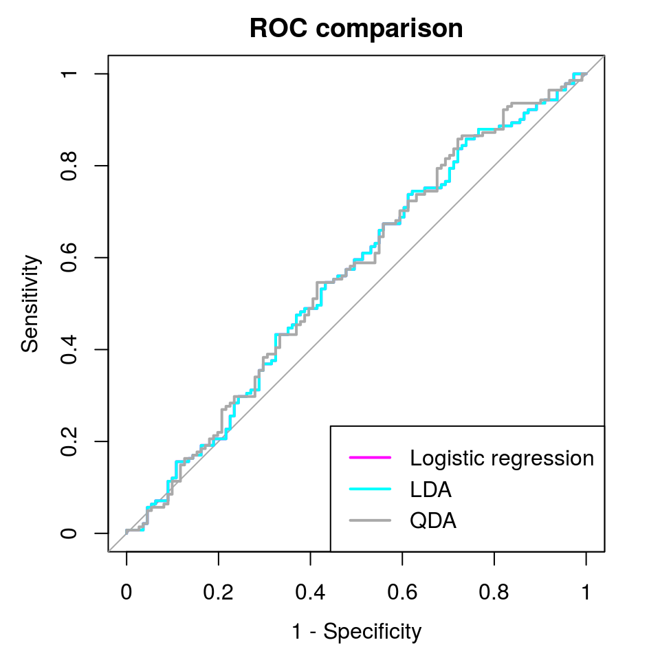

```r
legend(x = "bottomright", legend = c("Logistic regression", "LDA", "QDA"),
       col = c("magenta", "cyan", "darkgray"), lty = rep(1, 3),
       lwd = rep(2, 3))
```

# Some Theoretical Backgrounds

Two are the main approaches to Discriminant Analysis:

1. The first was from Fisher, who developed the Linear Discriminant Functions without formulating any distributional assumptions on data (excluding constant variance/covariance matrix within groups)
2. The second one, instead, assumes that the distribution of data is a multivariate normal, and basically applies LR methods to perform discriminations

## Linear Discriminant Functions

Let us suppose, for sake of simplicity, that two groups of observations are to be discriminated based on their measurements on two dimensions. We have then $g=2$ groups of observations; for each group we have $n$ observations on $p=2$ (continuous) dimensions.  
A possible representation of data points in a bidimensional Cartesian space could be the following:

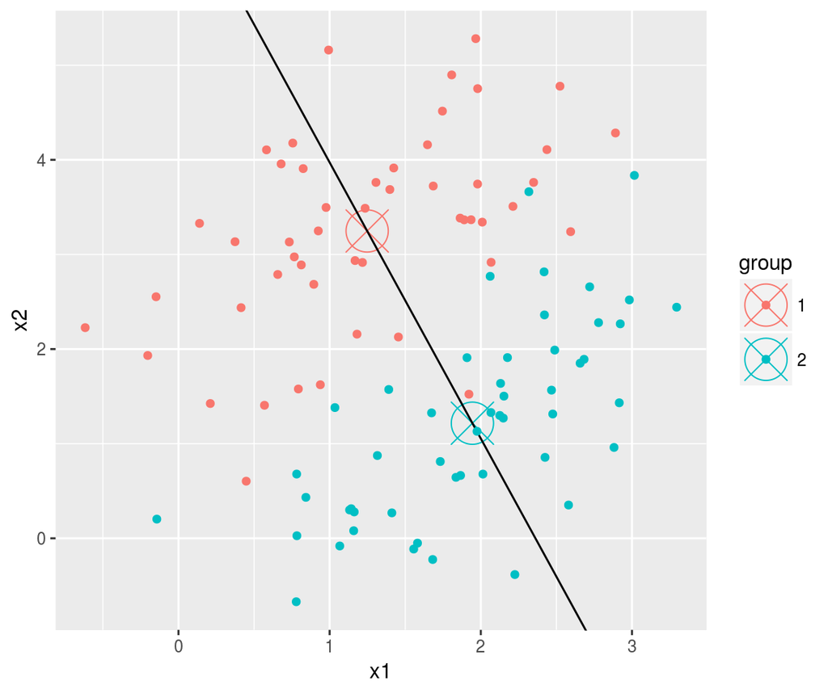

```r
require(ggplot2)
```

We must find the linear transformation of data points such that the two groups on this new dimension are “maximally separated”.
This is solved by finding the solution of:
$$\begin{matrix}
\max\\
\underline{a}
\end{matrix}\left\{\frac{\left [ \underline{a}^T \left(\underline{\overline{x}}_1-\underline{\overline{x}}_2 \right) \right ]}{\underline{a}^T S \underline{a}}\right\}$$
Where $S$ is the pooled variance/covariance matrix of two subgroups

The solution of above problem is:

$$\underline{a} = S^{-1} \left(\underline{\overline{x}}_1-\underline{\overline{x}}_2 \right)$$
and
$$z=\underline{a}^T \underline{x} = \left(\underline{\overline{x}}_1-\underline{\overline{x}}_2 \right)^T S^{-1} \underline{x}$$

Where $\underline{x}$ is a generic vector of observed data. $\underline{a}^T \underline{x}$ is the so-called *Fisher Linear Discriminant Function*.

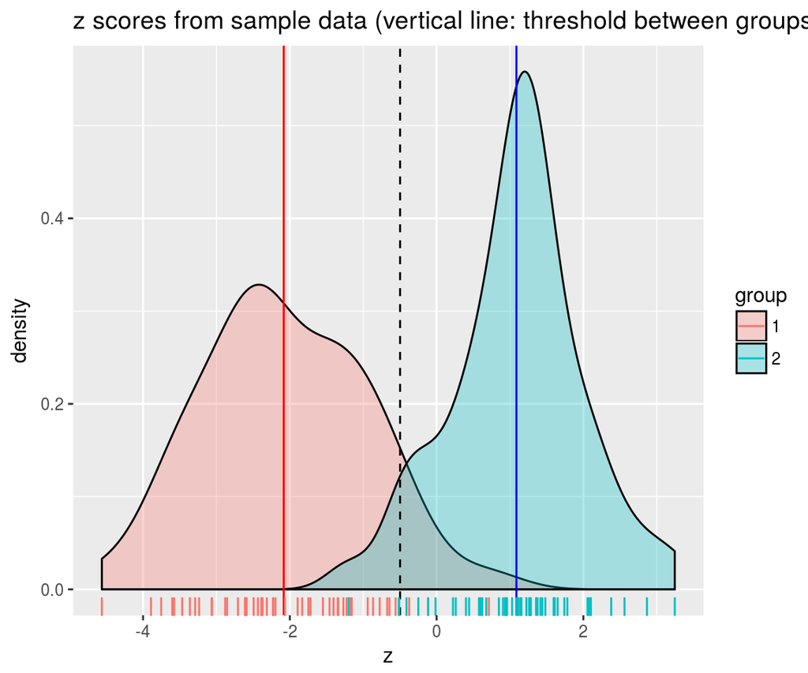

The thershold between groups is given by the mean of mean scores of the two groups, then the criterion to assign an observation to first group is:
$$\left(\underline{\overline{x}}_1-\underline{\overline{x}}_2 \right)^T S^{-1} \underline{x} - \left(\underline{\overline{x}}_1-\underline{\overline{x}}_2 \right)^T S^{-1} \left(\frac{\underline{\overline{x}}_1+\underline{\overline{x}}_2}{2} \right) >0$$

The above method may be applied also when $g >2$. In this case, the problem becomes more complex, and requires the maximization, with respect to the $\underline{a}$, of the function:
$$R = \frac{\underline{a}^T B \underline{a}}{\underline{a}^T W \underline{a}}$$
Under some constraints on $\underline{a}$ and $\underline{a}^T \underline{x}$ values.
In above formula, $B$ is an estimate of the “between” groups variance/covariance matrix, and $W$ is an estimated of “within” groups variance/covariance matrix.
In this case, $max\{p,g-1\}$ orthogonal Linear Discriminant Functions shall be obtained.

## Probability Models

An alternative approach to discrimination is via probability models.
Let $\pi_i (i=1, \cdots, g)$ denote the prior probabilities of the groups, and $p(\underline{x}|i)$ the densities of distributions of the observations for each group. Then the posterior distribution of belonging to $i$-th group after observing $\underline{x}$ is
$$p(i|\underline{x}) = \frac{\pi_i p(\underline{x} | i)}{p(\underline{x})} \propto \pi_i p(\underline{x} | i)$$
and it is fairly simple to show that the allocation rule which makes the smallest expected number of errors chooses the class with maximal $p(i | \underline{x})$; this is known as the *Bayes rule*.

Now suppose the distribution for group $i$ is multivariate normal with mean $\mu_i$ and covariance $\Sigma_i$ . Then the Bayes rule minimizes
$$Q_i = −2 \log(p(\underline{x} | i)) − 2 \log(\pi_i)
= (\underline{x} − \mu_i )^T\Sigma_i^{−1} (\underline{x} − \mu_i ) + \log(|\Sigma_i |) − 2 \log( \pi_i)$$

The first addendum of last term of above formula is the squared Mahalanobis distance to the group centre. The rule to assign observation to group $i$ that minimizes the above formula gives the *Quadratic Discriminant Function*.

If we suppose that the groups have a common covariance matrix $\Sigma$. Differences in the $Q_i$ are then linear functions of $\underline{x}$, and we can maximize $−Q_i /2$ or
$$L_i = \underline{x} \Sigma^{−1} \mu^T_i − \mu_i Σ^{−1} \mu^T_i /2 + \log(\pi_i)$$
If we substitute $\mu_i$ and $\Sigma$ with sample estimates (sample mean $\overline{\underline{x}}$ and sample within groups variance/covariance matrix $S$), then the above formula gives results that, for $\pi_i=1/g$, are equivalent to the the ones of Linear Discriminant Functions.